# 第9回 順伝播ニューラルネットワーク①（人工ニューロン・活性化と多層・勾配降下法・MLPRegressor）

経済データとプログラミングII

第9回

順伝播ニューラル  
ネットワーク①

曲げ方までデータから学び、坂を下って重みを決める

経済データとプログラミングII

第9回 — Topic01

人工ニューロンと重回帰

ニューロン 1 個は重回帰と同じ掛けて足す計算

## 第9回の道のり

1

重み付き和

実習：実行 データを読む準備

実習：写経 係数と重み

演習 9-1 遅行の重みの変更

2

曲げて足す

実習：写経 折れ線 3 本の和

演習 9-2 折れ目の急さの変更

3

坂を下る

実習：実行 坂下りの準備

実習：写経 坂下りと損失曲線

演習 9-3 学習率の変更

4

同じ物差し

実習：実行 分けてそろえる準備

実習：写経 20 ノードの学習

演習 9-4 隠れ層のノード数の比較

いまココ。ニューロン 1 個が、何を計算しているかを見る

## 前の回の振り返り

[figure not shown]

**前の回**：$x^2$ も説明変数に足して、K〜O に曲線 $\hat{y} = 19.2 - 8.4x + 1.0x^2$ を引いた

**7 日まで延ばす**：N・O は 2 時間で落ち着いているのに、6 日で 4.8 時間・7 日で 9.4 時間に戻る

## このトピックで学ぶこと

- **ここまで**：$x^2$（バイト日数の 2 乗）を説明変数に足すと、曲がった線が引けた
- **でも**：曲げ方（2 乗）は人が決めた  
  2 乗の線はどこかで必ず向きを変える（7 日で 9.4 時間）
- **問い**：曲げ方もデータに任せられないか  
  （ニュースの「AI」の中身はそういう仕組み）
- **進め方**：まず部品を見る。前半は 5 人の表、後半で景気動向指数

そこで、曲げ方を学ぶ機械の部品、**人工ニューロン**から見る

## 5 人の重回帰の式

前に学んだ**重回帰**：自習時間の見込みを、  
バイト日数 $x$ とサークル日数 $z$ の 2 つで説明した式（A〜E の 5 人）

$\hat{y} = 12.0 - 1.0x - 2.5z$

**$-1.0x$**：バイトを 1 日増やすと、見込みが 1.0 時間減る

**$-2.5z$**：サークルを 1 日増やすと、見込みが 2.5 時間減る

**$12.0$**：バイトもサークルも 0 日の人の見込み（切片）

計算の順に

$\hat{y} = (-1.0) \times x + (-2.5) \times z + 12.0$

同じ式。掛け算が先、足すのは最後

この先、この計算を何段もつなぐ。式より追いやすい絵に描き直す

## 5 人の重回帰のノード図

上の式を、計算の順に左から右へ描く（式と絵の同じ所は同じ色）

[figure not shown]

**ノード図**：計算の流れを、丸と矢印で描いた図（丸や箱がノード）

## A さんの数の流れ

A さん（バイト 1 日・サークル 1 日・実際の自習 9 時間）の数を、左から流す

[figure not shown]

式で書くと

$(-1.0) \times 1 + (-2.5) \times 1 + 12.0 = 8.5$

絵の流れと同じ（実際は 9 時間）

## ◼ 人工ニューロン

**人工ニューロン：入力に重みを掛けて足し、関数を 1 つ通す部品**

定義

$$\hat{y} = \text{関数}\big(\, w_1 \times (\text{入力 1}) + w_2 \times (\text{入力 2}) + b \,\big)$$

**ニューロン**：脳の神経細胞。入ってきた信号を足し合わせて、次へ伝える

**人工**：その働きをまねて、計算で作ったもの

**重み $w$**：入力に掛ける数 ⇔ 重回帰の係数（5 人では $-1.0$・$-2.5$）

**バイアス $b$**：最後に足す数 ⇔ 重回帰の切片（5 人では 12.0）  
前に出てきた欠落変数バイアス（偏り）とは別もの

**重み付き和**：かっこの中。入力に重みを掛けて足し、バイアスを足した数

**関数**：重み付き和を受け取って、値を返す。このトピックでは「そのまま返す」  
だから計算は重回帰と同じ

## 2 段つないだ重み付き和

関数が「そのまま返す」ニューロンを 2 つつなぐ  
1 段目の答えを 2 段目に入れる（例として 2 倍して 1 を足す）

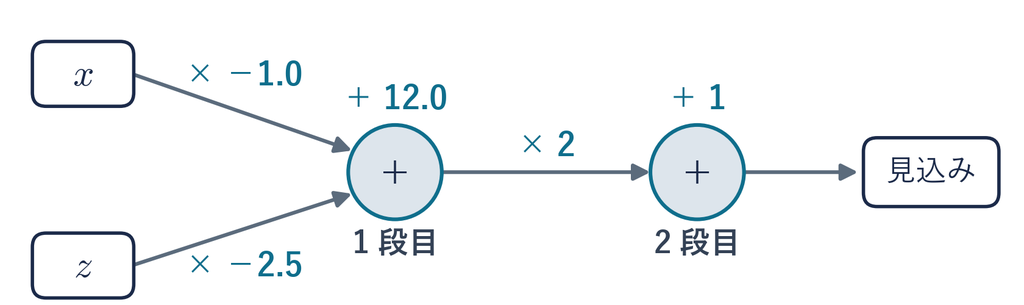

1 段目

$12.0 - 1.0x - 2.5z$

5 人の重み付き和

2 段目

$2 \times (12.0 - 1.0x - 2.5z) + 1 = -2.0x - 5.0z + 25.0$

かっこを外すと、また重み付き和

最後の関数がそのままだと、何段つないでも、  
代入すればまた重み付き和。線は曲がらない

## ニューロンの最後の関数

線を曲げるには、最後の関数を「そのまま返す」から替える

[figure not shown]

**線を曲げる関数**：重み付き和を、まっすぐでない形にして返す関数（次のトピックで使う）

**例 ReLU**：0 より下は 0、上はそのまま。だから 0 で折れ目が付く

## 1958 年のパーセプトロン

用語

**パーセプトロン**：重み付き和が境目の値（しきい値）を超えたら 1、  
超えなければ 0 を出す部品  
（1・0 は「はい・いいえ」の判定。例：景気が良い月か）

- **生まれ**：1958 年。人工ニューロンを使った最初の部品
- **中身**：しきい値で切る前は、5 人の式と同じ重み付き和
- **名前**：前に年表で見た名前（第 1 回）。その中身がこの部品
- **最後の関数**：パーセプトロンは、しきい値で 0・1 に切る関数。この授業は、  
  線を曲げる関数を使う（次のトピック）

## よくある失敗 脳の名前への期待

✕ 脳をまねたから賢い

名前が「ニューロン（神経  
細胞）」なので  
1 個でも重回帰より賢  
そうに見える

○ 1 個は重回帰と同じ計算

5 人の式も景気の式も、  
掛けて足すだけ  
計算は 1 文字も違わない

賢さは部品 1 個からではなく、線を曲げる関数と、  
つなぎ方から来る（次のトピック）

## 景気動向指数のニューロン

今度は景気動向指数で、同じ部品を見る  
（生産・雇用・売上などの統計を内閣府が毎月まとめた指数・497 か月）  
一致（今回の答え）：景気と同時に動く・先行：先に動く  
（新規の求人など）・遅行：あとから動く（失業率など）

[figure not shown]

前に出てきた重回帰 $-9.161 + 0.503 \times$ 先行 $+ 0.656 \times$ 遅行 が、そのままニューロン 1 個  
（先行が 1 上がると、一致の見込みが 0.503 上がる）

## ★ 41 年の山と谷と直線 1 本

今度は入力を月の通し番号 1 つ（1985 年 1 月が 1）にして、  
41 年の山と谷の形を線 1 本でなぞれるか試す

[figure not shown]

関数が「そのまま返す」ニューロン 1 個では、直線しか引けない。  
山と谷は追えない（$R^2$ 0.326）  
$R^2$：上下の動きの何割を線が説明できたか。形をなぞるだけで、予測ではない

## データを読む準備のセル

```python
!pip install -q japanize-matplotlib
import japanize_matplotlib
import numpy as np
import pandas as pd
import matplotlib.pyplot as plt
from sklearn.linear_model import LinearRegression
BASE = "ここに manaba の URL を貼る"
ci = pd.read_csv(BASE + "ci_composite.csv").dropna()
X = ci[["ci_leading", "ci_lagging"]]
y = ci["ci_coincident"]
print(len(ci))
```

ノートの準備のセル（写さず実行）。先に `BASE` の行の引用符の中を、  
manaba に載せた URL の最後の `/` までに書き換える  
入力 `X` は先行・遅行の 2 列、答え `y` は一致。  
空欄の行を落として `497` と出る

## 写経 1 係数と重みの書き写し

```python
m = LinearRegression().fit(X, y)
w1, w2 = m.coef_
b = m.intercept_
lead, lag = X.iloc[-1]
y_hat = w1 * lead + w2 * lag + b
print(round(w1, 3), round(w2, 3), round(b, 3))
print(round(y_hat, 1), round(m.predict(X.iloc[[-1]])[0], 1))
```

| 行 | 部品 | 渡すもの | できるもの |
| --- | --- | --- | --- |
| 1 | **当てはめる** `.fit` | 入力 `X`・答え `y` | 重回帰の模型 `m` |
| 2-3 | **呼び直す** | 係数 `.coef_`・切片 `.intercept_` | 重み `w1`・`w2`、バイアス `b` |
| 4 | **最後の月** `.iloc[-1]` | −1 は後ろから 1 番目 （2026 年 5 月） | 先行 `lead`・遅行 `lag` |
| 5 | **掛けて足す** | 重み × 入力 ＋ バイアス | 見込み `y_hat` |
| 6-7 | **見比べる** | 手の計算と `predict` （`[[-1]]` は表の形のまま 1 行） | `0.503 0.656 -9.161`・`122.7 122.7` |

## コードセルの写経と実行

1. **＋ コード**で空のセルを足す  
   （案内の文の下）
2. 写経 1 の 7 行を上  
   から写す
3. **▶** か **Shift + Enter** で実行  
   （Mac は Shift + return）
4. 重み・バイアスと、  
   見込み 122.7 を見る

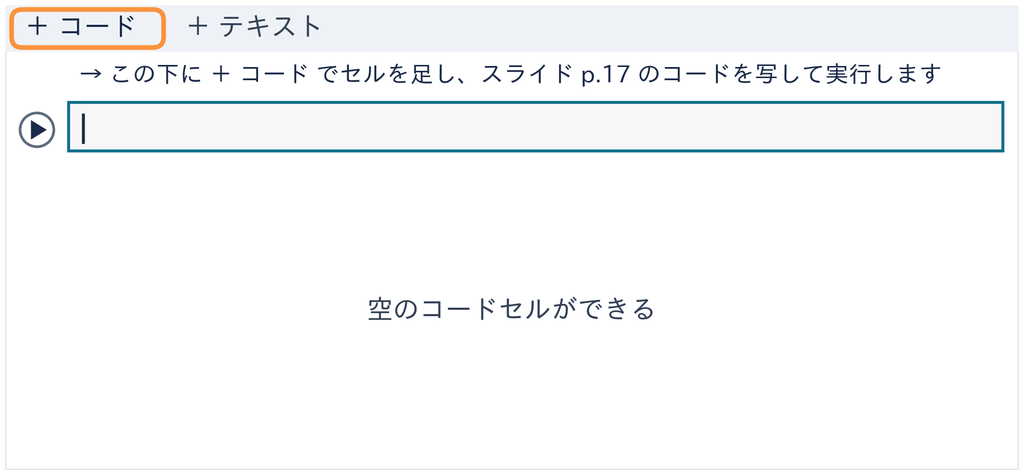

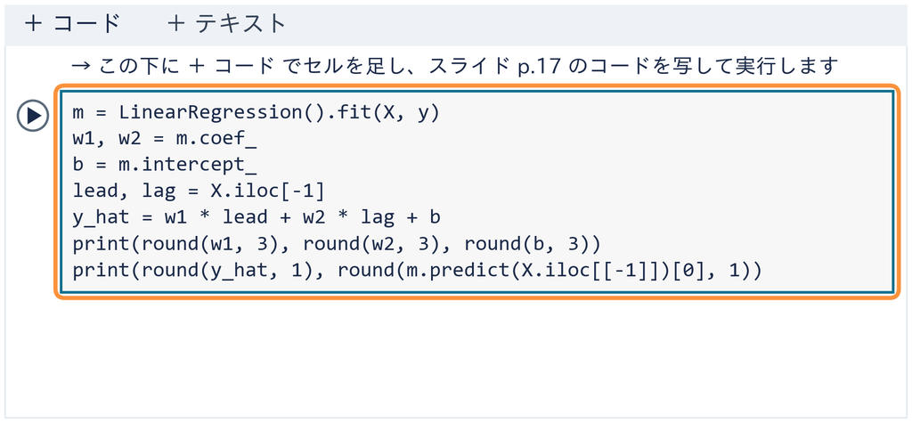

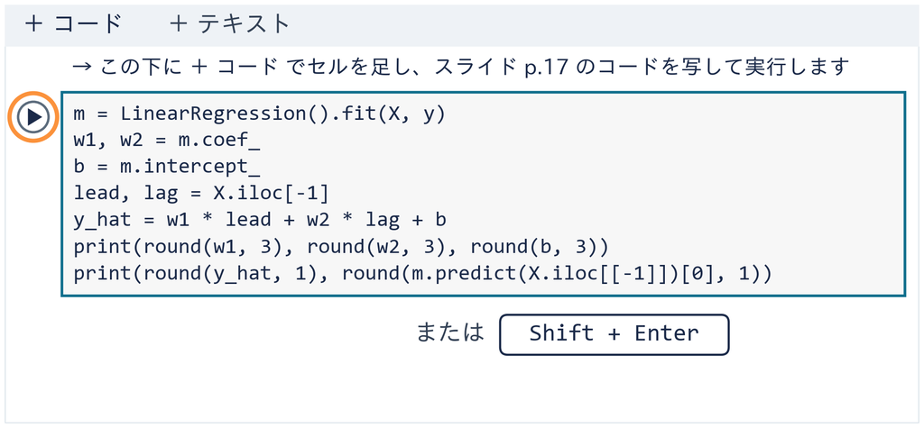

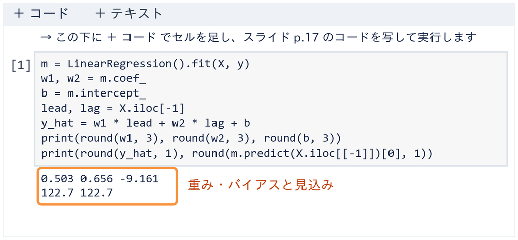

⏸ PAUSE 動画を止めて $2$ 分。`122.7 122.7` が出たら再生に戻る

## 演習 9-1 遅行の重みの変更

演習 9-1

遅行の重みを 0 にすると、最後の月の見込みは

```python
y_hat = w1 * lead + 0 * lag + b
```

1. **先に考える**：ⓐ 上がる ⓑ 下がる ⓒ 変わらない
2. **写して変える**：写経 1 の 7 行を新しいセルに写し、  
   5 行目の `w2` を `0` に（変えるのは 1 か所）
3. **終わり**：答え欄に ⓐ〜ⓒ と、出た見込み

⏸ PAUSE 動画を止めて $3$ 分。答えを書いたら再生に戻る

## 演習 9-1 の答え

答えは **ⓑ 下がる**。見込みは 122.7 から 49.6 へ  
出力は `0.503 0.656 -9.161` と `49.6 122.7`

遅行の項

$0.656 \times 111.5 \approx 73.1$

遅行の重み × 最後の月の遅行

見込み

$122.7 - 73.1 = 49.6$

先行の項とバイアスだけが残る

重みは、その入力がどれだけ効くかを決める数。0 にすると、  
その入力は見込みに入らない  
2 つめの 122.7 は元の模型 `m` のまま。遅行を外して作り直すと、  
先行の重みも変わる（前に出てきた肩代わり）

## まとめ

- ニューロン 1 個は、**重み付き和**を関数に通す部品。  
  関数がそのままなら、計算は重回帰と同じ
- 重み ⇔ 係数、バイアス ⇔ 切片。違いは最後の関数
- 何段つないでも、代入するとまた重み付き和。線は曲がらない
- この授業の外で：ニュースの「AI」は、  
  この部品に線を曲げる関数を入れて、たくさんつないだもの

ニューロン 1 個は、重回帰の計算に関数を 1 つ通す部品だった  
残った問い：直線しか引けない部品で、  
K〜O の曲がりはどう引くか。これを次のトピックで見る

経済データとプログラミングII

第9回 — Topic02

順伝播ネットワーク

線を曲げて足すと、曲げ方まで学べる

## 第9回の道のり

1

重み付き和

実習：実行 データを読む準備

実習：写経 係数と重み

演習 9-1 遅行の重みの変更

2

曲げて足す

実習：写経 折れ線 3 本の和

演習 9-2 折れ目の急さの変更

3

坂を下る

実習：実行 坂下りの準備

実習：写経 坂下りと損失曲線

演習 9-3 学習率の変更

4

同じ物差し

実習：実行 分けてそろえる準備

実習：写経 20 ノードの学習

演習 9-4 隠れ層のノード数の比較

いまココ。線を曲げて足すと、何が引けるかを見る

## このトピックで学ぶこと

- **ここまで**：ニューロン 1 個は、重み付き和に関数を通す部品。  
  関数がそのままだと、何段つないでも直線
- **でも**：前の回の 2 次の線は、曲げ方を人が決めたので  
  7 日で 9.4 時間に跳ね上がる  
  K〜O は 1〜2 日でぐっと減り、4 日を過ぎると減らない
- **問い**：直線を、どこかで曲げることはできないか
- **進め方**：前半は K〜O の 5 人、後半で景気動向指数

そこで、線を曲げる関数（**活性化関数**）を入れる

## ◼ 活性化関数 ReLU

**ReLU：負を 0 に切って、線を折る関数**

定義

$$\mathrm{ReLU}(\text{重み付き和}) = \max(0,\ \text{重み付き和})$$

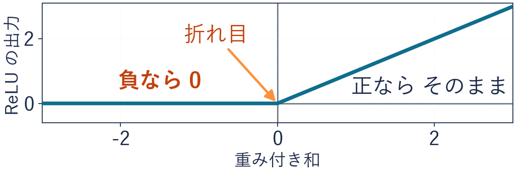

**max(0, 重み付き和)**：0 と重み付き和の大きいほう。重み付き和が負なら 0、正ならそのまま

**活性化関数**：重み付き和のあとに通して、線を曲げる関数

**決めごと**：負なら 0 は、そう決めた折り方。この授業は ReLU だけを使う

## K〜O の折れ線 1 本

折れ目を 2.5 日に置いた 1 本：$\hat{y} = 2.4 + 6.5 \times \max(0,\ 2.5 - x)$  
$2.5 - x$ は重み −1・バイアス 2.5 の重み付き和  
ことばでは、2.5 日に足りない日数（2.5 日を過ぎたら 0）  
読み方：2.5 日より 1 日少ないごとに自習が 6.5 時間多い。過ぎると 2.4 時間で一定

[figure not shown]

2.5 日を過ぎると 0 で切れて効かなくなる。そこが折れ目。  
$R^2$ は直線の 0.80 から 0.989 へ

## 折れ線 3 本の足し合わせ

今度は折れ目を 4・3・2 日の 3 か所に置き、1 本ずつ足す（5 人を通るように手で選んだ数）  
$\hat{y} = 2 + 1 \times \max(0,\ 4 - x) + 2 \times \max(0,\ 3 - x) + 3 \times \max(0,\ 2 - x)$

[figure not shown]

K さん（1 日）

$2 + 1 \times 3 + 2 \times 2 + 3 \times 1 = 2 + 3 + 4 + 3 = 12$

3 本の max の値は 3・2・1

同じ計算で L〜O も 6・3・2・2。3 本で 5 人ぴったり  
**急さ**：折れ目から 1 日離れるごとに見込みに足す時間（出力層の重み 1・2・3）  
例：K さんは 2 本目の折れ目 3 日から 2 日離れるので $2 \times 2 = 4$。  
線の傾きは折れ目ごとに急さの分だけ変わる

## ◼ 順伝播ネットワーク

**順伝播ネットワーク：折れ線を足し合わせて、曲げ方まで学ぶ仕組み**

[figure not shown]

**入力層・出力層**：入力層は $x$ を受け取る層。出力層は見込み $\hat{y}$ を出す層

**隠れ層**：入力でも答えでもない、あいだの層。データの表に値が出てこないので「隠れ」

**ノード**：隠れ層の箱 1 個。重み付き和を ReLU に通す、ニューロン 1 個

## 重みとバイアスと順伝播

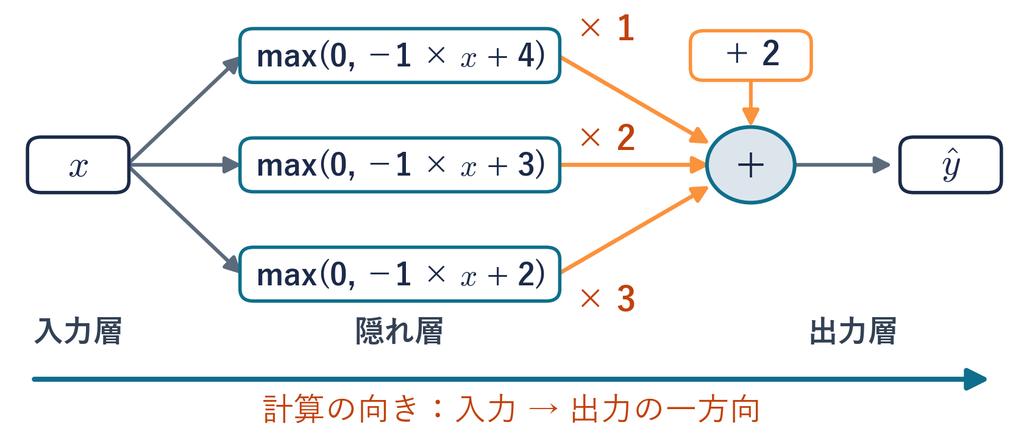

**重みとバイアス**：隠れ層は重み −1・バイアス 4・3・2（折れ目の位置）  
出力層は重み 1・2・3（折れ目の急さ）・バイアス 2

**順伝播**：入力から出力へ、一方向に計算を流すこと（順：前へ。伝播：次へ伝わる）

**MLP**：多層パーセプトロン。隠れ層を持つ順伝播ネットワーク。層を 3 つ重ねるので多層

## 2 次の線と折れ線の延長

[figure not shown]

2 次の線は 6 日 4.8・7 日 9.4 時間と跳ね上がる形を、人が押し付けた  
折れ線は 2.0 時間のまま  
どちらが当たるかはデータで確かめる。いまは折れ目を手で置いた  
重みをデータで決めれば、曲げ方もデータで決まる

## ✋ たしかめ 3 ノードでの山と谷

たしかめ

今度は景気動向指数で。ノード 3 個で、41 年の山と谷を追えるか

- **入力**：月の通し番号 1 つ（1985 年 1 月が 1）
- **答え**：その月の一致指数（497 か月）
- **ネットワーク**：隠れ層 1 つ・ReLU

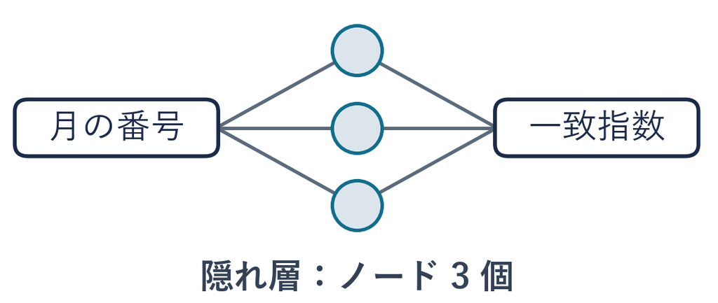

1. **ⓐ** ほとんど追える **ⓑ** 半分ほど追える **ⓒ** ほとんど追えない
2. 予想の材料：ノード 1 個で折れ目は 1 つまで。41 年の山と谷はずっと多い

⏸ PAUSE 動画を止めて $1$ 分。選んだら再生に戻る

## デモ：ノード数の実験室

数の話

入力は月の通し番号 1 つ、出力はその月の一致指数。  
隠れ層 1 つのネットワーク（ReLU）でなぞる。  
ノードは 1・2・3・5・10・20・50 の 7 通り

- **何を見るか**：ノードを増やすと、線は何回まで折れ曲がれるか。  
  形をなぞる力を見るだけで、来月を当てる話ではない
- **図の意味**：灰の点が一致指数（497 か月）、  
  青緑の線がネットのなぞった線。右に $R^2$（当てはまり）
- **操作**：隠れ層のノードのつまみ、戻す

ミッション つまみを右へ。  
線が山と谷を追いかけ始めるのは、ノードいくつから？

※ 次のスライドへ進むときは、デモの枠の外を一度クリックしてから ← → キーを押す

[interactive chart not shown]

## ★ ノード数と当てはまり

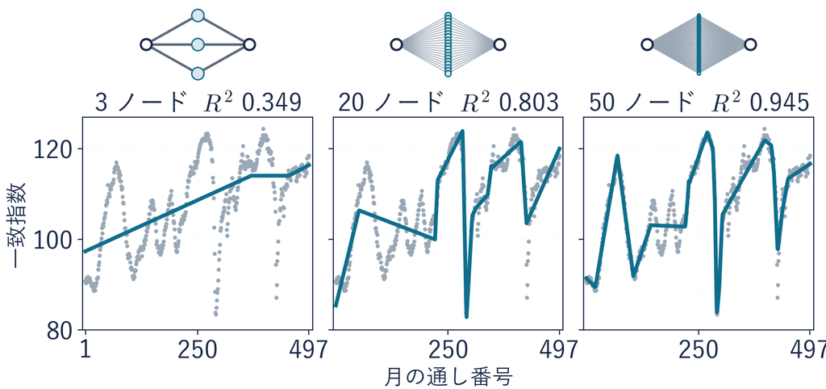

たしかめの答えは **ⓒ**。3 ノードでなぞれたのは右肩上がりの大きな傾きだけ  
$R^2$ は 1 ノード 0.326・3 ノード 0.349・10 ノード 0.575・  
20 ノード 0.803・50 ノード 0.945（折れ目は機械が探した。探し方は次のトピック）

ノードを増やせば、理論上はどんな形にも近づける。ただし、  
その重みを見つけられるかは別

## よくある失敗 当てはまりと予測の混同

✕ 0.945 なら来月も当たる

41 年の形をよくなぞれたので  
先の月も当たりそうに見える

○ 形をなぞっただけ

入力は月の番号だけ  
来月の景気の材料は入っていない

[figure not shown]

当たるかは、前に出てきた訓練とテストで測る  
（このあとのトピックで使う）

## 写経 2 折れ線 3 本の和

```python
x = np.arange(1, 8)
h1 = np.maximum(0, 4 - x)
h2 = np.maximum(0, 3 - x)
h3 = np.maximum(0, 2 - x)
y_hat = 2 + 1 * h1 + 2 * h2 + 3 * h3
print(pd.DataFrame({"x": x, "h1": h1, "h2": h2, "h3": h3,
                    "y_hat": y_hat}))
```

| 行 | 部品 | 渡すもの | できるもの |
| --- | --- | --- | --- |
| 1 | **日数を並べる** `np.arange` | 1 から 7 まで（8 の手前） | `x`（1〜7 日） |
| 2-4 | **隠れ層** `np.maximum(0, …)` | 折れ目 4・3・2 | 3 本の中身 `h1`・`h2`・`h3` |
| 5 | **出力層** | 急さ 1・2・3 とバイアス 2 | 見込み `y_hat` |
| 6-7 | **表で見る** `pd.DataFrame` | 5 つの列 | 7 行の表（1 日目は `3 2 1 12`） |

※ `np.maximum(0, 4 - x)` は、  
7 日分の $4 - x$ を 1 つずつ 0 と比べ、大きいほうを並べて返す  
※ 先に T1 の準備のセル（`np`・`pd` を読み込む）を実行しておく。  
表の左端の 0〜6 は行の番号

## コードセルの写経と実行

1. **＋ コード**で空のセルを足す  
   （案内の文の下）
2. 写経 2 の 7 行を上  
   から写す
3. **▶** か **Shift + Enter** で実行  
   （Mac は Shift + return）
4. `y_hat` の列 12・6・3・2・  
   2・2・2 を見る

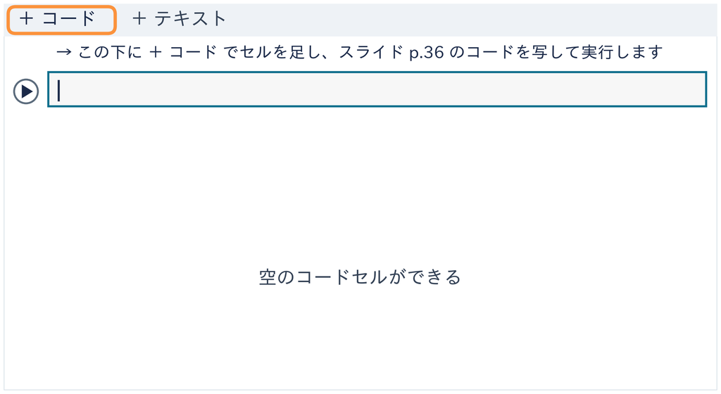

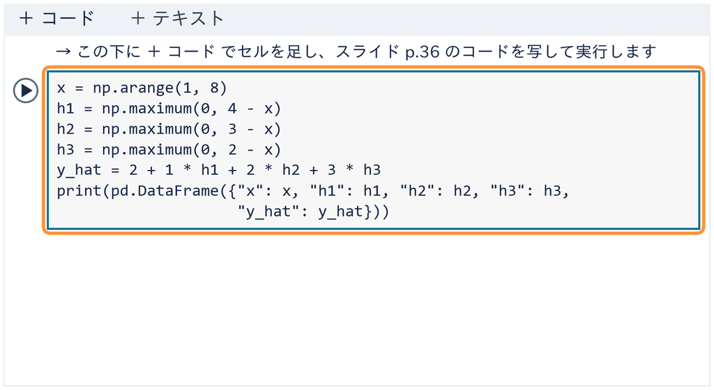

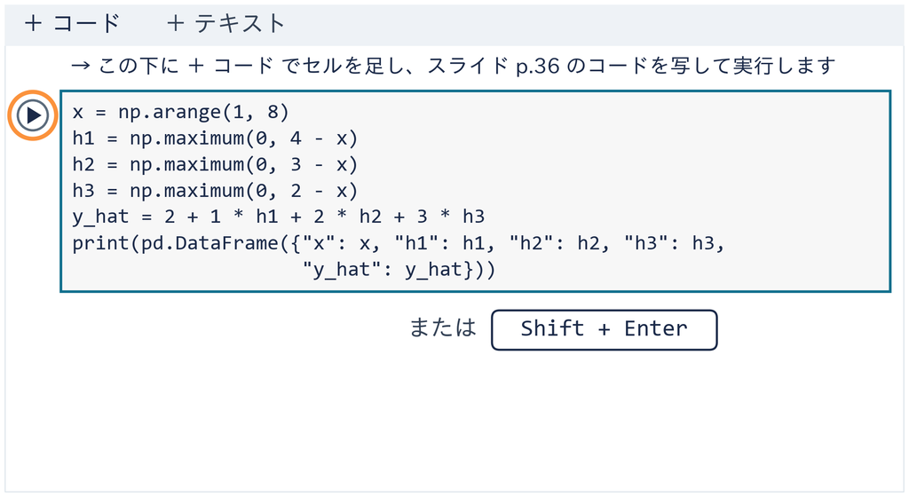

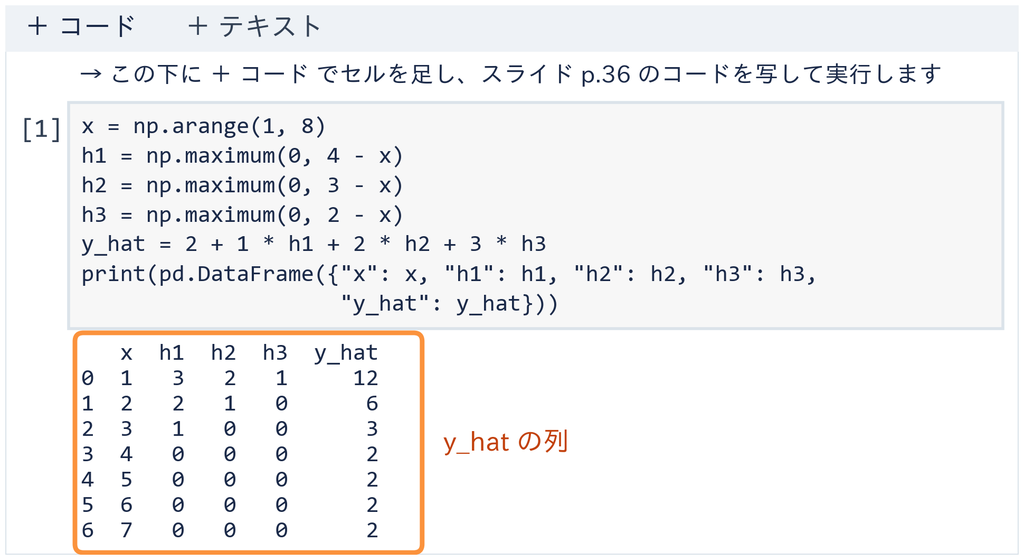

⏸ PAUSE 動画を止めて $2$ 分。7 行の表が出たら再生に戻る

## 演習 9-2 折れ目の急さの変更

演習 9-2

3 本目の急さ 3 を 0 にすると、1 日目の見込みは

```python
y_hat = 2 + 1 * h1 + 2 * h2 + 0 * h3
```

1. **先に考える**：ⓐ 12 のまま ⓑ 9 ⓒ 3
2. **写して変える**：写経 2 の 7 行を新しいセルに写し、  
   5 行目の `3 * h3` を `0 * h3` に
3. **終わり**：答え欄に ⓐ〜ⓒ と、2 日目から先が変わったか

⏸ PAUSE 動画を止めて $3$ 分。答えを書いたら再生に戻る

## 演習 9-2 の答え

答えは **ⓑ 9**。`y_hat` の列は 9・6・3・2・2・2・2

K さん（1 日）

$2 + 1 \times 3 + 2 \times 2 + 0 \times 1 = 9$

3 本目の 3 がまるごと消える

2 日目から先

$\max(0,\ 2 - x) = 0$

3 本目は 2 日目から 0。見込みは同じ

この 3 本は、折れ目より日数の少ない側だけで効く。  
だから 3 本目を 0 にすると 1 日目だけが変わる

## まとめ

- ReLU（負を 0 に切る）を通すと、重み付き和が折れ線になる
- 折れ線を足し合わせると、曲がった形が引ける
- K〜O の 5 人は、折れ線 3 本でぴったり
- 折れ目の位置と急さは、隠れ層と出力層の重みとバイアス

曲げて足すと、曲げ方まで引けた  
残った問い：その重みは誰が決めるのか。  
重回帰のような公式はあるか。これを次のトピックで見る

経済データとプログラミングII

第9回 — Topic03

勾配降下法と学習率

公式が無くても、損失が減る方へ少しずつ動かす

## 第9回の道のり

1

重み付き和

実習：実行 データを読む準備

実習：写経 係数と重み

演習 9-1 遅行の重みの変更

2

曲げて足す

実習：写経 折れ線 3 本の和

演習 9-2 折れ目の急さの変更

3

坂を下る

実習：実行 坂下りの準備

実習：写経 坂下りと損失曲線

演習 9-3 学習率の変更

4

同じ物差し

実習：実行 分けてそろえる準備

実習：写経 20 ノードの学習

演習 9-4 隠れ層のノード数の比較

いまココ。公式の無いネットの重みを、どう決めるかを見る

## このトピックで学ぶこと

- **ここまで**：重回帰の係数は、公式で一発で出た
- **でも**：T2 の折れ目は手で置いた。  
  50 ノードで山と谷をなぞった重みは、誰も手で置いていない  
  折れ目が入ると、折れる前と後で式が変わり、  
  重回帰のような公式が 1 本で書けない
- **問い**：では、ネットワークの重みはどう決めるか
- **進め方**：前半は 5 人 A〜E を $x$ だけで。後半で景気動向指数

そこで、坂を下るように重みを探す（**勾配降下法**）

## ◼ 損失関数

**損失関数：残差の二乗の平均で、小さいほど重みが良い**

ここでの損失はお金の損ではなく、見込みのずれの大きさ

定義

$$\text{MSE} = \frac{\text{残差の二乗の和}}{\text{人数}}$$

**残差**：実際の値から見込みを引いた数（1 人ごとのずれ）

**MSE**：平均二乗誤差。前に出てきた交差検証の誤差と同じ計算

**損失関数**：重みを入れると MSE が返る関数。重みを動かすと値が変わる

重みを決めるとは、損失がいちばん小さくなる重みを探すこと

## 2 つの重みの損失

5 人をバイト日数だけで、平均（バイト 3 日・自習 6 時間）からの離れで考える  
見込み：（自習の離れ）＝ $w$ ×（バイトの離れ）  
（平均の人 C は離れ 0・見込みも 0。だからバイアスは要らず、重みは $w$ の 1 本だけ）  
試す重みは $w = 0$（関係なし）と、前に出てきたバイト日数だけの回帰の係数 −2.0

| 人 | A | B | C | D | E |
| --- | --- | --- | --- | --- | --- |
| $x$ の離れ | −2 | −1 | 0 | 1 | 2 |
| $y$ の離れ | 3 | 4 | 0 | −4 | −3 |
| $w = 0$ の残差 | 3 | 4 | 0 | −4 | −3 |
| $w = -2$ の残差 | −1 | 2 | 0 | −2 | 1 |

$w = 0$

$(9 + 16 + 0 + 16 + 9) \div 5 = 10$

残差を二乗して平均

$w = -2$

$(1 + 4 + 0 + 4 + 1) \div 5 = 2$

損失が小さいほうが良い重み

## 5 人の損失の谷

重み $w$ を −4 から 0 まで動かして、損失を並べる  
（5 人分を足して 5 で割り、整理すると $10 + 8w + 2w^2$）

[figure not shown]

谷底は $w = -2$（損失 2）。  
前に出てきたバイト日数だけの回帰の係数 −2.0 と同じ数  
人数で割っても谷底の位置は変わらない。だから損失の谷底は、  
前に出てきた最小二乗の線と同じ

## ◼ 勾配降下法

**勾配降下法：損失が減る方へ、重みを少しずつ動かす**

定義

$$\text{新しい } w = w - \eta \times \text{坂の傾き}$$

[figure not shown]

**坂の傾き（勾配）**：損失の坂がどちらへ上がっているか（5 人では $8 + 4w$）  
$w$ を 0 から 0.01 動かすと損失は 10 → 10.0802。1 あたり約 8

**なぜ引く**：傾きが正（右上がり）なら、左へ動くと下る。だから傾きの逆へ

**$\eta$**：学習率（コードでは `lr`）。傾きに掛けて、1 歩で動く量を決める数

## 学習率 0.1 の坂下り

[figure not shown]

1 歩目

$0 - 0.1 \times 8 = -0.8$

傾き $8 + 4 \times 0 = 8$

2 歩目

$-0.8 - 0.1 \times 4.8 = -1.28$

傾き $8 + 4 \times (-0.8) = 4.8$

3 歩目

$-1.28 - 0.1 \times 2.88 = -1.568$

傾き $8 + 4 \times (-1.28) = 2.88$

50 歩目

$w \approx -2.000$

谷底に着く

谷の全体を知らなくても、いまの坂の傾きだけで下れる。  
谷底に近いほど傾きが小さく、1 歩で動く量も小さい

## ◼ 学習率

**学習率：傾きに掛ける、1 歩の大きさ**

定義

$$\text{1 歩で動く量} = \eta \times \text{坂の傾き}$$

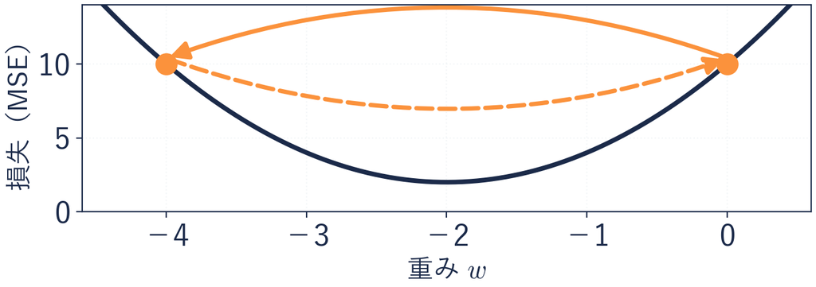

0.5 の 1 歩目

$0 - 0.5 \times 8 = -4$

谷底 −2 を飛び越える

0.5 の 2 歩目

$-4 - 0.5 \times (-8) = 0$

傾き $8 + 4 \times (-4) = -8$。元に戻る

学習率 0.1 なら、坂の傾き 8 の 0.1 倍の 0.8 だけ動く  
0.5 は 0 と −4 を行き来し、損失は 10 のまま

## 4 つの学習率の道

今度は横が歩数、縦が重み $w$（谷底は −2）

[figure not shown]

**0.01**：小さすぎる。50 歩でも −1.74 で、谷底の手前（歩数を増やせばいずれ着く）

**0.1**：50 歩で −2.000。谷底に着く

**0.5**：0 と −4 を行き来する。損失は 10 のまま

**0.6**：跳ね返るたびに遠ざかる。8 歩目で損失 1744（5 人の谷では 0.5 が境）

0.1 までは大きいほど早いが、大きすぎると谷を飛び越える。  
小さすぎると 50 歩では着かない

## ✋ たしかめ 坂下りの行き先

たしかめ

今度は景気動向指数で。  
重み 2 本とバイアスを 0 から坂を下ると、着く先は

- **入力**：先行・遅行（前に出てきた標準化で、平均 0・標準偏差 1 に）
- **見込みたい数**：一致（同じく標準化）。重み 2 本それぞれに坂の傾きがある
- **歩き方**：学習率 0.1 で 50 歩。損失は MSE
1. **ⓐ** 前に出てきた重回帰の係数と同じ **ⓑ** 重回帰とは別の  
   係数 **ⓒ** どこにも着かない

⏸ PAUSE 動画を止めて $1$ 分。選んだら再生に戻る

## ★ 50 歩で着いた重み

たしかめの答えは **ⓐ**。着いた重みを元の単位に戻して、重回帰の係数と並べる

|  | 切片（バイアス） | 先行の重み | 遅行の重み |
| --- | --- | --- | --- |
| 坂下り 50 歩 | −9.159 | 0.503 | 0.656 |
| 坂下り 2000 歩 | −9.161 | 0.503 | 0.656 |
| 重回帰（公式） | −9.161 | 0.503 | 0.656 |

損失は 1.000（全員を平均で見込んだとき）から 0.0895 へ。  
ずれが最初の約 9% まで減った（1 − $R^2$ 0.9105）

**勾配降下法：公式が無くても、坂を下れば同じ谷底に着く**

谷が 1 つの重回帰で、答えと同じ所に着くと確かめた  
谷がいくつもあるネットワークで着く先は、次のトピックで見る

## よくある失敗 学習の意味の取り違え

✕ 学習とは 497 か月を覚えること

「学習」という言葉から  
データを全部しまい込む  
ように見える

○ 残ったのは 3 つの数

−9.159・0.503・0.656 だけ  
497 か月そのものは残っていない

学習とは、損失が小さくなる重みを探すこと

重みの数が桁違いに多いと、話が少し変わる。それはあとで

## デモ：学習率の実験室

数の話

重み 2 本（先行・遅行）のニューロンを、0 から 50 歩、勾配降下法で下る  
1 歩ごとに、傾きと逆向きへ「傾き × 学習率」だけ動く

- **何を見るか**：学習率を大きくすると、谷底（★）に早く着くのか
- **図の意味**：左は損失の谷を上から見た地図（等高線：損失が同じ点を結ぶ線）  
  と下った道、★ は重回帰の答え  
  右は損失曲線（歩数ごとの損失・縦は 1 目盛で 10 倍）、点線が谷底の損失
- **操作**：学習率のボタン 5 つ（0.001・0.1・0.6・0.65・0.7）、歩数のつまみ（0〜50）、戻す

ミッション 学習率のボタンを押して歩数を進める。  
どこから谷底に着けなくなる？

※ 次のスライドへ進むときは、デモの枠の外を一度クリックしてから ← → キーを押す

[interactive chart not shown]

## 損失曲線と誤差逆伝播

実験室の答え：0.6 までは着き、0.65 から飛び出す。境はおよそ 0.63  
どこから飛び出すかは谷の形で決まる（5 人の谷は 0.5、景気の谷はおよそ 0.63）

[figure not shown]

**損失曲線**：横に繰り返しの回数、縦に損失を描いた線  
平らな所は下りが止まった所（谷底とは限らない）

**誤差逆伝播**：重みが何十個あっても、傾きをまとめて計算するやり方  
前に年表で見た名前。計算は機械がする

## 坂下りの準備のセル

```python
Xz = ((X - X.mean()) / X.std(ddof=0)).to_numpy()
yz = ((y - y.mean()) / y.std(ddof=0)).to_numpy()
def descend(lr, steps=50):
    w, b, losses = np.zeros(2), 0.0, []
    for _ in range(steps):
        err = yz - (Xz @ w + b)
        grad_w = -2 * Xz.T @ err / len(yz)
        grad_b = -2 * err.mean()
        w = w - lr * grad_w
        b = b - lr * grad_b
        losses.append(((yz - (Xz @ w + b)) ** 2).mean())
    return w, b, losses
print(Xz.shape)
```

[output not shown]

## 写経 3 坂下りと損失曲線

```python
w, b, losses = descend(lr=0.1)
plt.plot(losses)
plt.xlabel("繰り返しの回数")
plt.ylabel("損失（MSE）")
plt.show()
print(round(losses[-1], 4))
```

| 行 | 部品 | 渡すもの | できるもの |
| --- | --- | --- | --- |
| 1 | **坂を下る** `descend` | 学習率 `lr=0.1`（50 歩） | 重み `w`・バイアス `b`・損失を順に並 べたリスト `losses` |
| 2-5 | **損失曲線** `plt.plot` | 50 個の損失 | 下って平らになる線 |
| 6 | **50 歩目の損失** `losses[-1]` | リストのいちばん後ろ | `0.0895` |

## コードセルの写経と実行

1. **＋ コード**で空のセルを足す  
   （案内の文の下）
2. 写経 3 の 6 行を上  
   から写す
3. **▶** か **Shift + Enter** で実行  
   （Mac は Shift + return）
4. 損失曲線と、  
   最後に出る損失を見る

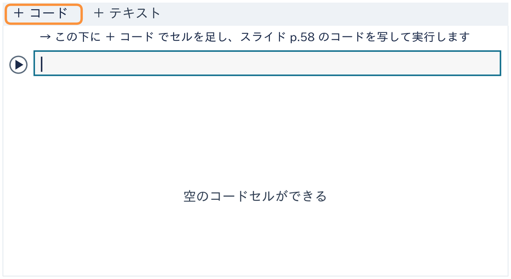

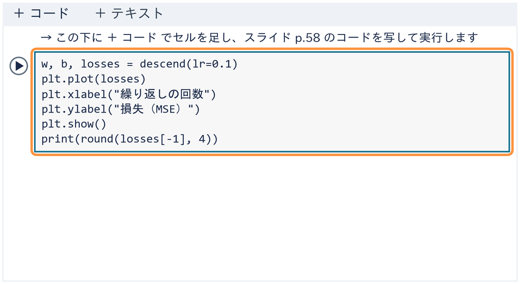

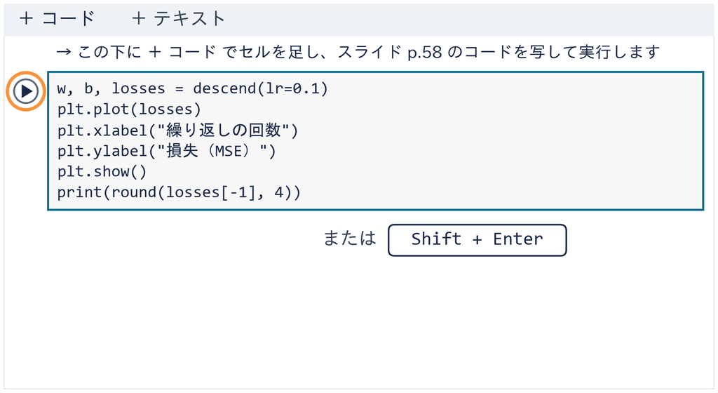

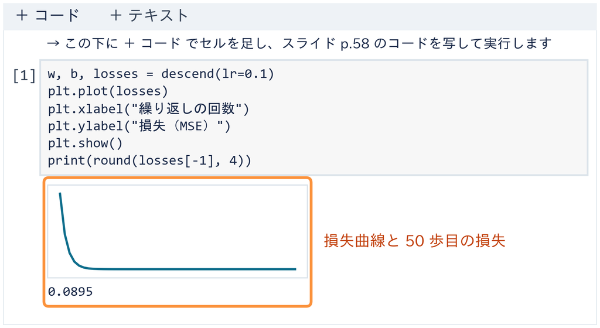

⏸ PAUSE 動画を止めて $2$ 分。`0.0895` が出たら再生に戻る

## 演習 9-3 学習率の変更

演習 9-3

学習率を 0.001 と 0.7 に替えると、50 歩目の損失は

```python
w, b, losses = descend(lr=0.001)
```

1. **先に考える**：0.001 は ⓐ 着く ⓑ 50 歩ではまだ途中  
   0.7 は ⓐ 着く ⓑ 飛び出す
2. **写して変える**：写経 3 を新しいセルに写し、`0.1` を `0.001` に  
   実行したら、`0.7` に替えてもう一度実行
3. **終わり**：答え欄に 2 つの損失と、谷底に着いたかを 1 行

⏸ PAUSE 動画を止めて $3$ 分。答えを書いたら再生に戻る

## 演習 9-3 の答え

**0.001**：`0.7509`。ⓑ 50 歩ではまだ途中（谷底 0.0895 までまだ遠い）

**0.7**：`1204859053.7206`（約 12 億）。ⓑ 飛び出す（谷から跳ね出していく）

大きすぎると飛び出し、小さすぎると 50 歩では着かない  
下り切ったかは、損失曲線で確かめる

## まとめ

- 損失関数：残差の二乗の平均（MSE）。重みを決めるとは、  
  損失が最小の重みを探すこと
- 勾配降下法：いまの傾きの逆へ、  
  学習率 × 傾きだけ動かす、を繰り返す
- 景気動向指数で 50 歩下ると、  
  重回帰と同じ係数に着いた（谷が 1 つなので）

学習とは、損失が減る方へ重みを少しずつ動かすこと  
残った問い：重みが何十個にもなるネットワークでも、  
坂下りを手で書くのか。これを次のトピックで見る

経済データとプログラミングII

第9回 — Topic04

多層パーセプトロンの実装

重回帰と同じ物差しで当たりを比べる

## 第9回の道のり

1

重み付き和

実習：実行 データを読む準備

実習：写経 係数と重み

演習 9-1 遅行の重みの変更

2

曲げて足す

実習：写経 折れ線 3 本の和

演習 9-2 折れ目の急さの変更

3

坂を下る

実習：実行 坂下りの準備

実習：写経 坂下りと損失曲線

演習 9-3 学習率の変更

4

同じ物差し

実習：実行 分けてそろえる準備

実習：写経 20 ノードの学習

演習 9-4 隠れ層のノード数の比較

いまココ。ネットを sklearn で動かし、重回帰と同じ物差しで比べる

## このトピックで学ぶこと

- **ここまで**：坂を下れば、公式が無くても重みが決まる
- **でも**：重みが何十個にもなると、坂下りの関数を自分で書くのは大変
- **問い**：曲げ方まで学べる NN は、  
  見ていない月の一致指数を重回帰より予測できるか  
  同じ分け方・同じ物差し（テストの MSE）で比べたい
- **進め方**：前半は K〜O の 5 人、後半で景気動向指数

そこで、sklearn の **`MLPRegressor`** に坂下りを任せる

## ◼ 多層パーセプトロン

用語

**多層パーセプトロン（MLP）**：隠れ層を持つ順伝播ネットワーク

[figure not shown]

- **中身**：パーセプトロン（重み付き和をしきい値で切る部品）を層に重ね、  
  しきい値の代わりに ReLU を通す
- **道具**：`MLPRegressor`（数を予測する回帰の道具）。`fit` で学び、`predict` で当てる

## K〜O の 10 ノードの NN

K〜O の 5 人を、隠れ層のノード 10 個の `MLPRegressor` に渡す  
（折れ目は置かない。重みは坂下りで決まる）

[figure not shown]

5 人を通り、6・7 日目も 2.03〜2.13 時間（最初の重みを 3 通りに変えても同じ）  
折れ目の位置を、ネットワークが自分で見つけた

## よくある失敗 ノード数の決めつけ

[figure not shown]

✕ 3 ノードで十分

K〜O は折れ線 3 本でぴったりだった  
だから 3 個で足りそうに見える

○ 初期値しだいで水平線

くじ 1 では 5 人とも 5.0 時間  
ノード 3 個とも全員に 0 を返し  
坂の傾きが 0 になって下れない

初期値：坂下りを始める最初の重み。`random_state`（くじの番号）で決まる  
分け方のくじとは別。水平線が出たら、くじを変えるかノードを増やす

## ◼ MLPRegressor の手順

STEP は 4 つ。分け方の手順は前と同じ  
（4 分の 1 をテスト・くじの番号 42）。497 か月なら訓練 372・テスト 125

手順

STEP 1X と y を標準化する（平均と標準偏差は訓練だけで決める）

STEP 2`MLPRegressor` を作る（ノード数・`tol`・上限・くじ）

STEP 3`fit` で学ぶ（中で坂を下る）

STEP 4損失曲線を見て、見込みを元の単位に戻し、テストの MSE を測る

`tol`：1 回の繰り返しで損失が減る量の目安。これより小さい状態が続いたら止める  
既定は `1e-4`（0.0001）、この回は `1e-6`（0.000001）

## hidden_layer_sizes とネットワーク図

`hidden_layer_sizes`：隠れ層ごとのノードの数を並べたタプル（数 1 つ＝隠れ層 1 つ）

[figure not shown]

左の 2 つの点：先行・遅行 右の点：一致指数の見込み 枠：タプルの数と、その隠れ層

写経 4 は `hidden_layer_sizes=(20,)` 演習 9-4 は `hidden_layer_sizes=(2,)`

## y をそろえる理由

- **出発点**：重みは 0 に近い小さい数から出発する。最初の見込みはほぼ 0
- **一致指数**：83.4〜124.4（100 前後）。そのままだと谷底がはるか遠い
- **だから**：y も平均 0・標準偏差 1 にそろえて学ぶ（X は前と同じ作法で標準化）
- **戻す**：見込みを元の単位に戻し、重回帰と同じ MSE で測る

そろえるのは学ぶときだけ。比べる物差しは、元の単位のテストの MSE

## ✋ たしかめ 1 ノードの NN と重回帰

たしかめ

今度は景気動向指数で。ノード 1 個の NN のテストの MSE は

- **重回帰**：テストの MSE は 10.43
- **ネットワーク**：隠れ層 1 つ・ReLU

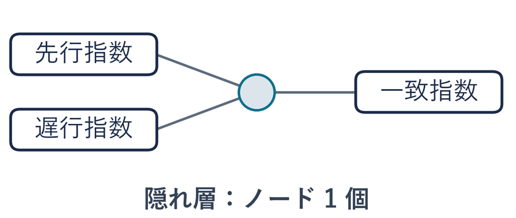

1. **ⓐ** 重回帰よりずっと小さい **ⓑ** ほぼ同じ **ⓒ** ずっと大きい
2. 予想の材料：ノード 1 個は、折れ目が 1 つしかない重み付き和

⏸ PAUSE 動画を止めて $1$ 分。選んだら再生に戻る

## ★ ノード数とテストの MSE

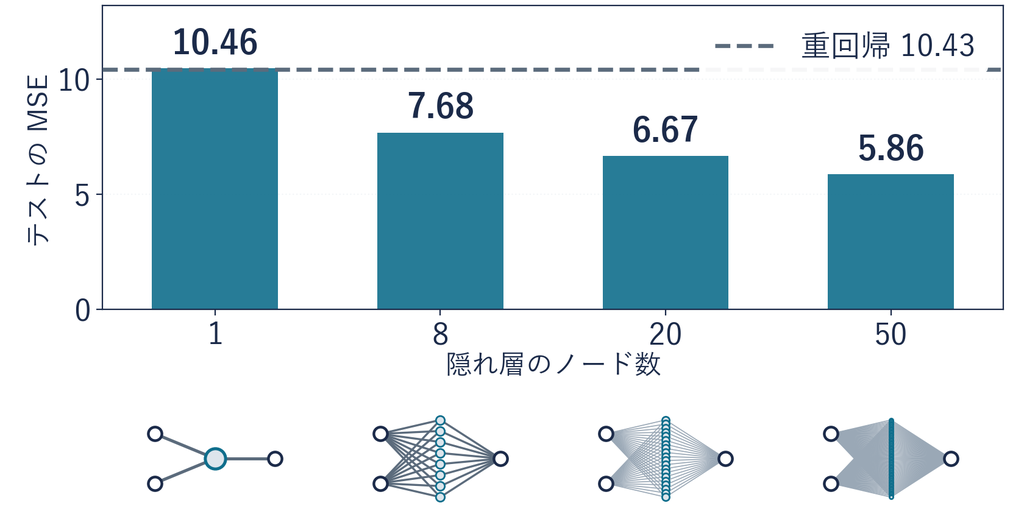

たしかめの答えは **ⓑ**（1 ノード 10.46・重回帰 10.43）

**8・20・50**：7.68・6.67・5.86。この 4 通りでは、ノードが多いほどテストの MSE が小さい

**$R^2$ で**：テストの 125 か月で、重回帰 0.883 → 50 ノード 0.934  
（全 497 か月の 0.9105 とは別の測り方）

**くじ 10 通り**：50 ノードのくじを変えると 5.66〜6.51  
だから「勝った」ではなく「この分け方では小さい」と言う

## よくある失敗 早すぎる打ち切り

[figure not shown]

✕ NN は重回帰に負ける

既定のままの 8 ノードは 11.73  
重回帰の 10.43 より大きい

○ 下る途中で止まった

既定は 176 回で打ち切り。  
まだ下っていた  
遅らせる  
（`tol=1e-6`・上限 5000 回）と 7.68

止まったのが谷底か手前かは、損失曲線で見る（図の横は 1 目盛で回数が 10 倍）

## 分けてそろえる準備のセル

```python
from sklearn.model_selection import train_test_split
from sklearn.preprocessing import StandardScaler
from sklearn.neural_network import MLPRegressor
from sklearn.metrics import mean_squared_error
Xtr, Xte, ytr, yte = train_test_split(X, y, test_size=0.25,
                                      random_state=42)
sx = StandardScaler().fit(Xtr)
sy = StandardScaler().fit(ytr.to_frame())
def test_mse(model):
    pred = model.predict(sx.transform(Xte)).reshape(-1, 1)
    return mean_squared_error(yte, sy.inverse_transform(pred).ravel())
lin = LinearRegression().fit(Xtr, ytr)
mse_lin = mean_squared_error(yte, lin.predict(Xte))
print(len(Xtr), len(Xte), round(mse_lin, 2))
```

ノートの準備のセル（写さず実行）。5〜6 行は前と同じ手順の分け方。  
7〜8 行で訓練だけから平均と標準偏差  
9〜11 行の `test_mse` は見込みを元の単位に戻して MSE を  
測る。`372 125 10.43` と出る

## 写経 4 20 ノードの学習

```python
mlp = MLPRegressor(hidden_layer_sizes=(20,), tol=1e-6,
                   max_iter=5000, random_state=42)
mlp.fit(sx.transform(Xtr), sy.transform(ytr.to_frame()).ravel())
plt.plot(mlp.loss_curve_)
plt.xlabel("繰り返しの回数")
plt.ylabel("損失")
plt.show()
print(mlp.n_iter_, round(test_mse(mlp), 2))
```

| 行 | 部品 | 渡すもの | できるもの |
| --- | --- | --- | --- |
| 1-2 | **STEP 2 作る** `MLPRegressor` | `(20,)`：隠れ層 1 つにノード 20 個・`tol`・上限 5000 回・初期 値のくじ 42 | 模型 `mlp` |
| 3 | **STEP 3 学ぶ** `.fit` | そろえた訓練の X と y （`ravel` で 1 列に戻す） | 坂を下った重み |
| 4-7 | STEP 4 損失曲線 `loss_curve_` | 回ごとの損失 | 下って平らになる線 |
| 8 | STEP 4 テストの MSE `test_mse` | テストの 125 か月 | `2625 6.67`（回数と MSE） |

## コードセルの写経と実行

1. **＋ コード**で空のセルを足す  
   （案内の文の下）
2. 写経 4 の 8 行を上  
   から写す
3. **▶** か **Shift + Enter** で実行  
   （Mac は Shift + return）
4. 損失曲線と、  
   テストの MSE 6.67 を見る

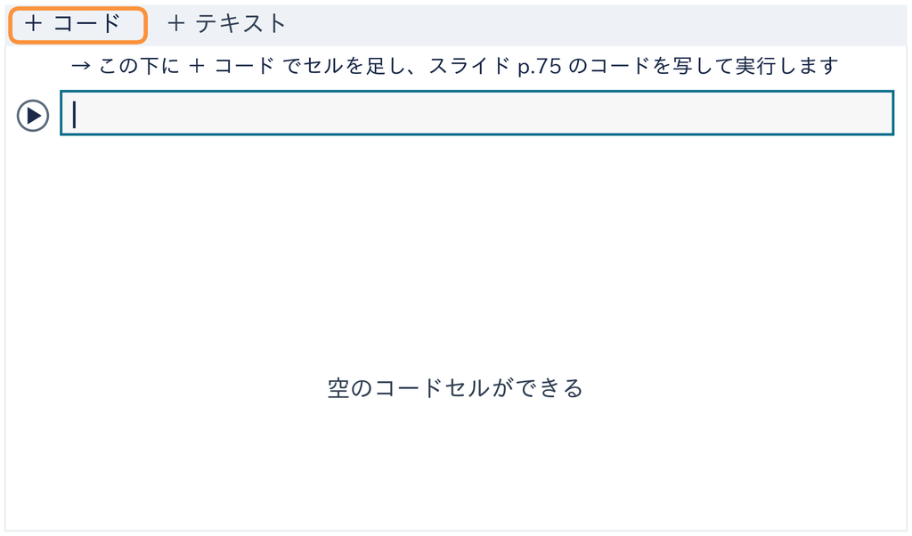

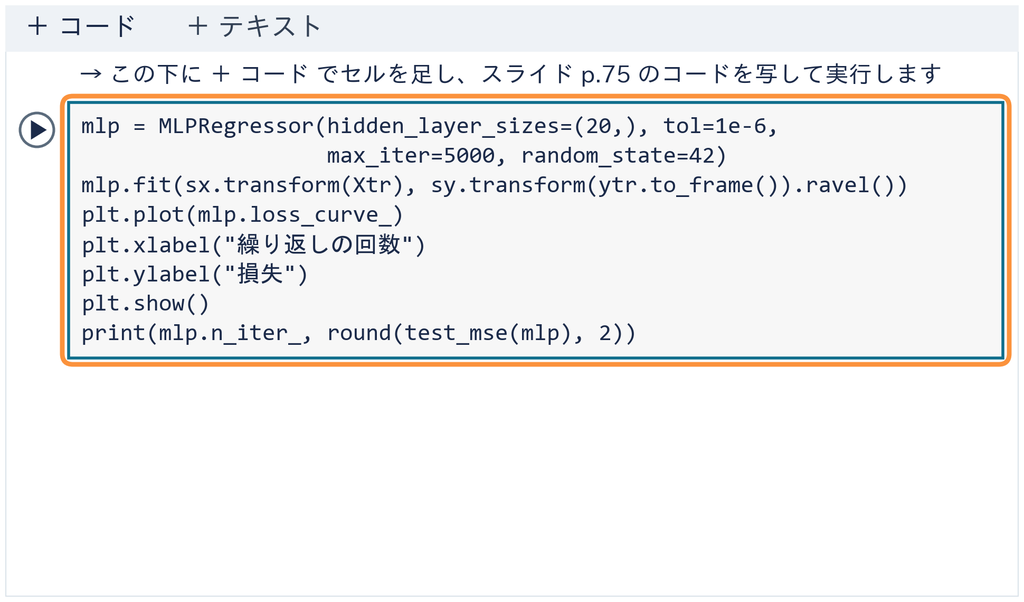

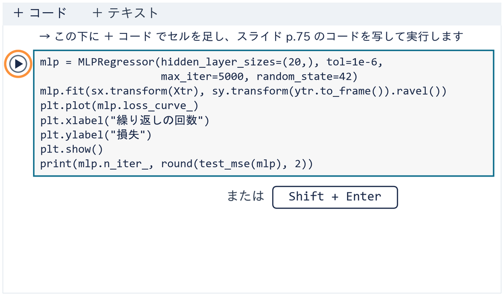

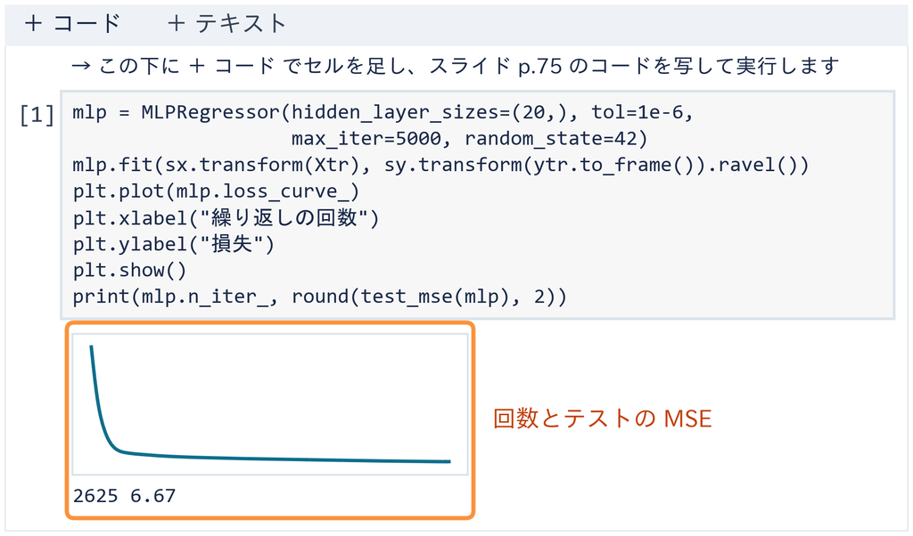

⏸ PAUSE 動画を止めて $2$ 分。`6.67` が出たら再生に戻る

## 演習 9-4 隠れ層のノード数の比較

演習 9-4

隠れ層のノードを 2 個と 5 個にすると、テストの MSE は

```python
mlp = MLPRegressor(hidden_layer_sizes=(2,), tol=1e-6,
                   max_iter=5000, random_state=42)
```

1. **先に考える**：重回帰（10.43）より ⓐ 両方小さい ⓑ  
   5 個だけ小さい ⓒ 両方大きい
2. **写して変える**：写経 4 を新しいセルに写し、`(20,)` を `(2,)` に  
   実行したら、`(5,)` に替えてもう一度実行
3. **終わり**：答え欄に 2 つのテストの MSE と、分かったことを 1〜2 行

⏸ PAUSE 動画を止めて $3$ 分。答えを書いたら再生に戻る

## 演習 9-4 の答え

答えは **ⓐ 両方小さい**。2 個 9.01・5 個 8.34  
（出力は `1037 9.01`・`2697 8.34`）  
どちらも重回帰の 10.43 より小さい

**比べ方**：分け方（372／125）と物差し（テストの MSE）をそろえたので、差が読める

**読めるもの**：NN の重みには標準誤差も p 値も付かない  
重回帰の「先行が 1 上がると一致が 0.503 上がる」が言えない  
見込みを出すだけなら困らない

## 第 9 回のまとめ

**部品**：ニューロン 1 個は、重回帰と同じ重み付き和

**曲げて足す**：ReLU で折った線を足し合わせると、曲げ方まで引ける

**坂を下る**：公式が無いので、損失が減る方へ重みを少しずつ動かす

**比べる**：`MLPRegressor` を、重回帰と同じ分け方・同じ物差しで並べる

ニューロン 1 個は重回帰と同じ重み付き和。  
曲げて足すと曲げ方までデータから学べ、  
公式が無いので、損失が減る方へ重みを少しずつ動かして探す

この授業の外で：卒論で「直線でない関係も試した（NN を使った）」と書くときは、  
同じ分け方・同じ物差しで並べる